# Data journalism project: The MCU & Diversity, a Blog entry

Matamoros_Carolina

19 de mayo de 2018

#### Main page:

Over the last 10 years Marvel Studios created the Marvel Cinematic Universe (MCU) and today it holds most of the highest grossing movies of all times. For many their success is derived from creating a cohesive interconnected universe, for others it is because it delves into real world problems like protectionism, weapon counter trafficking, oversight and international regulation, etc. Nevertheless, what this research will try to answer is if their success is related to the diversity of its cast and characters, given the recent entry and success of Black Panther and Infinity War, it may very well be a driver of their success.

#### Blog Entry:

## Can diversity (of gender and race) be a secret driver of the success behind the Marvel Cinematic Universe?

One part of today’s entertainment is entirely different from how it was when I was a little girl, nowadays discussion and interest in comics seems more mainstream and common. The MCU certainly had a role to play in such a shift, they have been in business of around 10 years since the release of Iron Man in 2008 and currently they hold 4 of the top 10 highest grossing movies of all time and all of their 19 released movies are within the top 100 [@[The Numbers](https://www.the-numbers.com/box-office-records/worldwide/all-movies/cumulative/all-time)].

[figure not shown]

@[MCU Wikia](http://marvelcinematicuniverse.wikia.com/wiki/Marvel_Cinematic_Universe)

Therefore, as a fan and also as a student of public policy, I’m interested discovering if there is something else that has driven the success of the MCU. With the shock derived by the Black Panther, a movie with mainly non-white cast, with women with agency and power, and with the underlaying problem of international refugees and protectionism, I couldn’t help but feel curious about the diversity factors involved, can they imply more success for a blockbuster?

To answer this question, I acknowledge the great work performed by Walt Hickey [@[Comic Books Are Still Made By Men, For Men And About Men](https://fivethirtyeight.com/features/women-in-comic-books/)], where he researches a similar question but for the entire enterprise of comics. He recognizes that the industry was created by and for white male, that the medium of comic shops limited the audience and made it even more specialized and as such it was a medium of entertainment closed only to them. Nevertheless, to have lived the success introduction of the characters and their stories in the silver screen, changed the demographic, now girls like me [non-white, not form the US, and who don’t have English as their mother tongue] and people even more different from the original client/user cluster, are not only being introduced but grown within a world with those narratives.

Therefore, to expect a better overall (Not just from the US) reception grow in the movies is fairly logical. Now they have a bigger demographic to be concerned about, not only white american boys.

Using R I downloaded 3 different sources of information to see how that information behaved together, the reported scores of critics and fans from rotten tomatoes[@[MCU Rotten Tomatoes](https://www.rottentomatoes.com/franchise/marvel_cinematic_universe)], the demographic general information from the MCU Wikia[@[MCU Wikia](http://marvelcinematicuniverse.wikia.com/wiki/Marvel_Cinematic_Universe)] and their collected box office from The Number[@[MCU The Numbers](https://www.the-numbers.com/movies/franchise/Marvel-Cinematic-Universe#tab=summary)].

By looking at the graph of Worldwide Box Office rate (to have it in the same scale as the rates all was divided by the highest grossing film of the MCU, Infinity War with over 1.8 Billion USD) jointly with the percentage of females, percentage of Americans and the score of the experts in Rotten Tomato. It showed that across the board the perception remains constantly high regarding the MCU with the success that it has, nonetheless the highest grossing movies show that apparently not as many Americans and a slight higher female cast may be desirable.

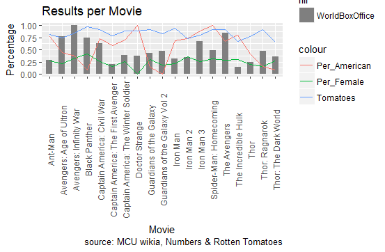

Nevertheless, the general constant approval of the brand and its product as well as the constant underrepresentation of women show that sadly the enterprise is still very much by and for men.

It is important to note that to download the demographic data for all the characters, some of them (mostly extras) were discarded as well as those who lacked their Wikia summary. As a whole, 260 characters were described and by using their gender, citizenship and specie, it was possible to estimate the rate of those variables for each of the movies according to which characters that appeared accordingly. This jointly with the rotten tomatoes scores (both from the and the box office numbers enabled the development of the following summary table by released movie of the MCU.

A Knitr table.

| Movie | ProductionBudget | DomesticOpeningWeekend | DomesticBox.Office | WorldwideBox.Office | Release.Date | Tomatoes | PopCorn | Per_Female | Per_American | Per_Human |
| --- | --- | --- | --- | --- | --- | --- | --- | --- | --- | --- |
| Iron Man | 186000000 | 102118668 | 318604126 | 585171547 | 2008-05-02 | 94 | 91 | 0.2105263 | 0.6842105 | 1.0000000 |
| The Incredible Hulk | 137500000 | 55414050 | 134806913 | 265573859 | 2008-06-13 | 67 | 71 | 0.3000000 | 0.8000000 | 1.0000000 |
| Iron Man 2 | 170000000 | 128122480 | 312433331 | 621156389 | 2010-05-07 | 73 | 72 | 0.3636364 | 0.7272727 | 1.0000000 |
| Thor | 150000000 | 65723338 | 181030624 | 449326618 | 2011-05-06 | 77 | 76 | 0.2083333 | 0.4166667 | 0.4583333 |
| Captain America: The First Avenger | 140000000 | 65058524 | 176654505 | 370569776 | 2011-07-22 | 79 | 74 | 0.1666667 | 0.5833333 | 1.0000000 |
| The Avengers | 225000000 | 207438708 | 623279547 | 1519479547 | 2012-05-04 | 92 | 91 | 0.2857143 | 0.6666667 | 0.9047619 |
| Iron Man 3 | 200000000 | 174144585 | 408992272 | 1215392272 | 2013-05-03 | 80 | 78 | 0.2592593 | 0.8888889 | 1.0000000 |
| Thor: The Dark World | 150000000 | 85737841 | 206362140 | 644602516 | 2013-11-08 | 66 | 77 | 0.2727273 | 0.0909091 | 0.4090909 |
| Captain America: The Winter Soldier | 170000000 | 95023721 | 259746958 | 714401889 | 2014-04-04 | 89 | 92 | 0.2592593 | 0.7037037 | 1.0000000 |
| Guardians of the Galaxy | 170000000 | 94320883 | 333172112 | 771051335 | 2014-08-01 | 91 | 92 | 0.3000000 | 0.1500000 | 0.1500000 |
| Avengers: Age of Ultron | 330600000 | 191271109 | 459005868 | 1408218722 | 2015-05-01 | 75 | 83 | 0.2222222 | 0.4444444 | 0.7777778 |
| Ant-Man | 130000000 | 57225526 | 180202163 | 519338048 | 2015-07-17 | 82 | 86 | 0.2727273 | 0.7727273 | 1.0000000 |
| Captain America: Civil War | 250000000 | 179139142 | 408084349 | 1153304495 | 2016-05-06 | 91 | 89 | 0.2631579 | 0.7368421 | 0.9473684 |
| Doctor Strange | 165000000 | 85058311 | 232641920 | 677541920 | 2016-11-04 | 89 | 86 | 0.0000000 | 1.0000000 | 1.0000000 |
| Guardians of the Galaxy Vol 2 | 200000000 | 146510104 | 389813101 | 863197744 | 2017-05-05 | 83 | 88 | 0.1904762 | 0.0000000 | 0.0000000 |
| Spider-Man: Homecoming | 175000000 | 117027503 | 334201140 | 880210429 | 2017-07-07 | 92 | 88 | 0.3125000 | 1.0000000 | 0.9687500 |
| Thor: Ragnarok | 180000000 | 122744989 | 315058289 | 850653412 | 2017-11-03 | 92 | 87 | 0.1538462 | 0.1538462 | 0.1538462 |
| Black Panther | 200000000 | 202003951 | 697784785 | 1344838950 | 2018-02-16 | 97 | 79 | 0.4166667 | 0.0833333 | 1.0000000 |
| Avengers: Infinity War | 300000000 | 257698183 | 595032959 | 1813732959 | 2018-04-27 | 84 | 91 | 0.3333333 | 0.3703704 | 0.5185185 |
| Totals | 3629100000 | NA | 6566907102 | 16667762427 | NA | NA | NA | NA | NA | NA |
| Averages | 191005263 | 127988506 | 345626690 | 877250654 | NA | NA | NA | NA | NA | NA |

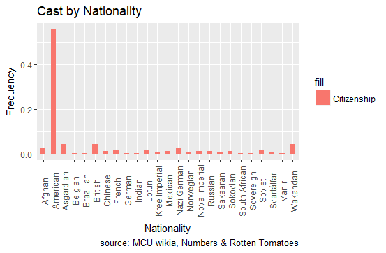

This approach has showed that sadly the universe is still focused on its original demographic but the high success of Black Panther, Civil War and all the Avengers suggests that that may be changing as was shown in the first graph.

A Knitr table.

|  | Estimate | Std. Error | t value | Pr(>\|t\|) |
| --- | --- | --- | --- | --- |
| (Intercept) | -1.465296e+09 | 4.723570e+08 | -3.1020951 | 0.0077999 |
| Tomatoes | 1.114092e+07 | 5.153919e+06 | 2.1616403 | 0.0484542 |
| Per_Female | 9.768772e+08 | 5.311410e+08 | 1.8392049 | 0.0871866 |
| Per_American | -4.121736e+07 | 1.482029e+08 | -0.2781144 | 0.7849897 |
| ProductionBudget | 6.201007e+00 | 9.027523e-01 | 6.8690014 | 0.0000077 |

A Knitr table.

|  | x |
| --- | --- |
| value | 16.97179 |
| numdf | 4.00000 |
| dendf | 14.00000 |

A Knitr table.

| x |
| --- |
| 0.7801854 |

To conclude though the industry remains focused heavily in the original demographic of comic costumers, the blockbuster hits and their success in the last few movies do suggest that that maybe they should focus more in more diverse characters, and cast. To research it may be of interest to see how the screen writer constitution has changed, can we expect more diversity in there as well? For now, I’m certain that the MCU will continue to delve into real world problem issues while maybe increasing the diversity of their cast and characters.

In here other graphs that may be of interest

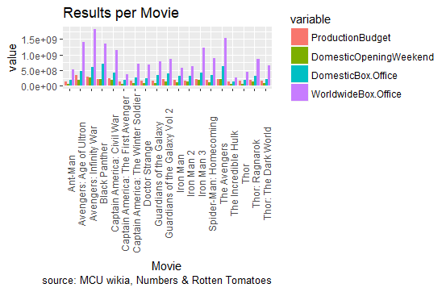

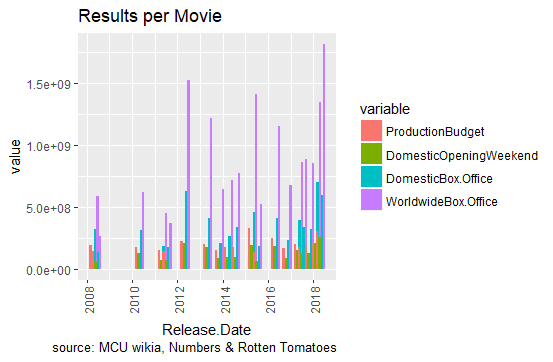

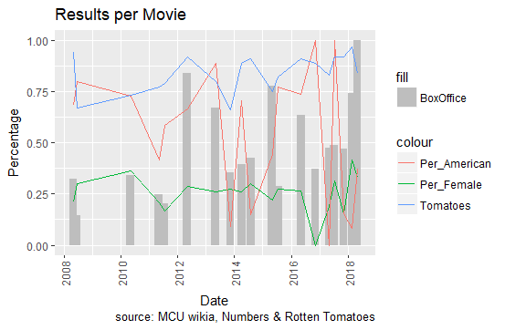

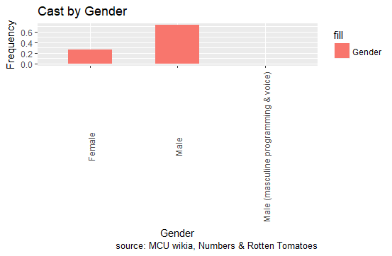

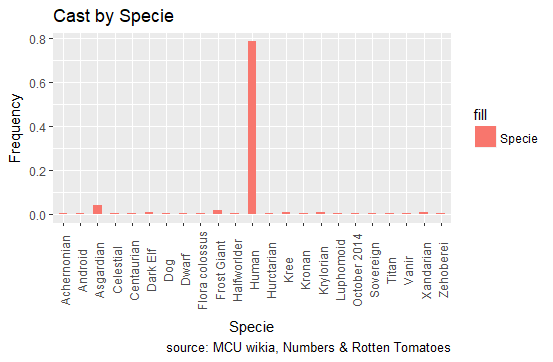